# Homework week 39

Created 4 October 2021 by Adela Sobtkova, updated 3 October 2023 by Sofie

2023-12-18

Downloading our dataset into our r-script

```r
library(tidyverse)
library(ggplot2)
```

“Created 4 October 2021 by Adela Sobtkova, updated 3 October 2023 by Sofie”

## Homework for week 39, consisting of two assignments, A and B.

### B) working with homicides in western Europe

This exercise is based on the dataset provided by [OurWorldInData project](https://ourworldindata.org/homicides) based at the Oxford University.

## The long-term trend in Homicides in Western Europe

Understanding how homicide rates have changed prior to the modern era requires the help of historians and archivists. Manuel Eisner, a criminology professor at the University of Cambridge, and his colleagues published the Historical Violence Database a compilation of data on long-term trends in homicide rates, in addition to qualitative information such as the cause of death, perpetrator and victim. This database is limited to countries with relatively complete historical records on violence and crime – mainly Western Europe and the US.

Starting in the second half of the nineteenth century, these European regions have consistent police records of those accused of murder or manslaughter and annual counts of homicide victims. To go back further in time, reaching as far back as the thirteenth century, Eisner collected estimates (from historical records of coroner reports, court trials, and the police) of homicide rates made in over ninety publications by scholars.

Homicide rates – measured as the number of homicides per 100,000 individuals – up to 1990 are sourced from Eisner’s (2003) publication and the Historical Violence Database.

Are homicide rates in Europe today lower or higher than in the past? Using the provided dataset, display and describe the long-run homicide rates for the five European regions: Italy, England, Germany, Netherlands and Scandinavia.

## Load the available data from ourworldindata.org

You should always interrogate the source of your data. Who compiled it, from where, what is missing, how representative the data are? Check the data/Metadata.txt to learn about the data provenance.

```r
Western_Europe <- read_csv("data/homicide-rates-across-western-europe.csv")
```

## Inspect the data

How clean and analysis-ready is the dataset? Do you understand what the column names represent? What is the difference between rate and homicide number?

```r
head(Western_Europe)
```

```
## # A tibble: 6 × 4
##   Entity  Code   Year Homicide rate in Europe over long-term (per 100,000) (ho…¹
##   <chr>   <chr> <dbl>                                                      <dbl>
## 1 England <NA>   1300                                                         23
## 2 England <NA>   1550                                                          7
## 3 England <NA>   1625                                                          6
## 4 England <NA>   1675                                                          4
## 5 England <NA>   1725                                                          2
## 6 England <NA>   1775                                                          1
## # ℹ abbreviated name:
## #   ¹`Homicide rate in Europe over long-term (per 100,000) (homicides per 100,000 people)`
```

Ok, the data look good except for the column `Homicide rate in Europe over long-term (per 100,000)` which is not very easy to work with.

- Use the `names()` function and assignment key to relabel this column to `homicides_per_100k`

```r
names(Western_Europe) <- c("entity", "code", "year", "homicides_per_100k")
head(Western_Europe)
```

```
## # A tibble: 6 × 4
##   entity  code   year homicides_per_100k
##   <chr>   <chr> <dbl>              <dbl>
## 1 England <NA>   1300                 23
## 2 England <NA>   1550                  7
## 3 England <NA>   1625                  6
## 4 England <NA>   1675                  4
## 5 England <NA>   1725                  2
## 6 England <NA>   1775                  1
```

Now, that you have looked at what the data looks like and what it represents, and streamlined it, let’s see what big picture it contains.

## Let’s see what the long-term trend is in homicides

- use `ggplot()` function and remember the`+` at the end of the line
- chose a meaningful `geom_......()` for geometry (hint: points are not great)
- load `Year` on the `x` axis and `homicides_per_100k` column in y axis
- to color individual country entries consistently, assign the country column to the argument `color`.
- provide meaningful title and axis labels
- remember to change the `eval` flag so that the code chunk renders w hen knitted

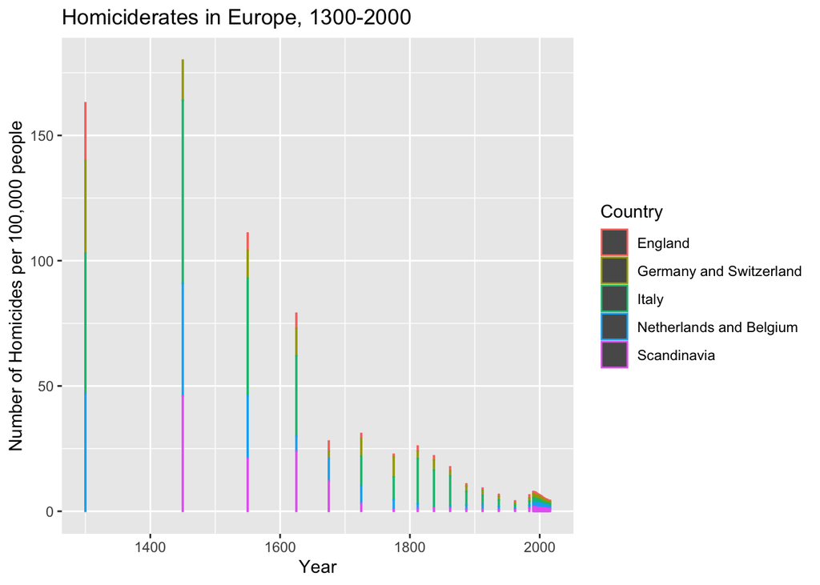

```r
ggplot(data = Western_Europe) +
  geom_col(aes(x = year, y = homicides_per_100k, color = entity)) +
  labs(title = "Homiciderates in Europe, 1300-2000") +
  labs(x = "Year", y = "Number of Homicides per 100,000 people") +
  labs(color = "Country")
```

Alright, the homicide rates should all be descending over time. What a comfort. But the viz is not super clear. Let’s check the rates for individual countries.

## Uncouple the homicides of individual countries for easier view

You can visualize each country’s trend separately by adding an extra argument to the ggplot, the `facet_wrap()` and feeding it the country column. If in doubt, check your ggplot tutorial and your country column name for exact usage.

- reuse the ggplot from the chunk above
- insert `facet_wrap()` after the specification of geometry to split countries in separate charts
- change the facet “layout” to two columns and three rows so that the trends are easier to see in horizontal layout.

```r
ggplot(data = Western_Europe) +
 geom_col(aes(x = year, y = homicides_per_100k, color = entity)) +
  facet_wrap(~entity, ncol=2)+
  labs(title = "Homiciderates in Europe, 1300-2000") +
  labs(x = "Year", y = "Number of Homicides per 100,000 people") +
  labs(color = "Country")+
  theme(legend.position = "bottom")
```

[output not shown]

### A) Visualize the duration of reign among Danish kings through time (showing the diachronic trend from ca 900 - today on the x axis) with ggplot.

##### Data input of our danish regents

```r
danish_regents <- read_csv("data/Danish_regents_tidy.csv")
```

##### Seeing the data colnames, so that we can work with them, to help us make a function

```r
colnames(danish_regents)
```

```
## [1] "Regent_Order"   "Monarch"        "Birth_year"     "Death_Year"
## [5] "Start_of_Reign" "End_of_reign"   "Reign_Sum"
```

##### We decide to plot with the %>% function and use ggplot to make a visualization using geom_col.

##### Plotting a diachronic blue line through the ggplot to show a tendency

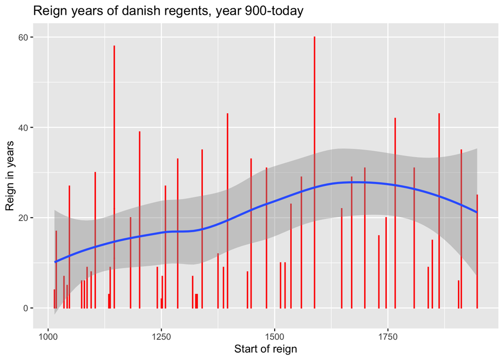

```r
danish_regents %>%
  ggplot(aes(x=Start_of_Reign,y=Reign_Sum))+
  geom_col(alpha=0.8, width=0.8, color="red")+
  geom_smooth()+
  labs(x="Start of reign", y="Reign in years")+
  labs(title="Reign years of danish regents, year 900-today")
```

## Compare the trends in homicide with the pattern of reign duration among Danish rulers through time.

- Load your Danish king dataset. Hopefully it is tidy and your years and duration of reign are all numeric.
- You need to have a consistent way of plotting the rulers’ reign on the x axis, so I recommend you create a midyear column by calculating the middle of each monarch’s rule (Hint: `midyear` = `endyear` - (`endyear`-`startyear`)/2)
- Start a ggplot plotting midyear on x axis and duration on y axis
- Try `geom_smooth()` for geometry
- Provide meaningful labels and a title
- How would you characterize the trend compared to the homicides above?

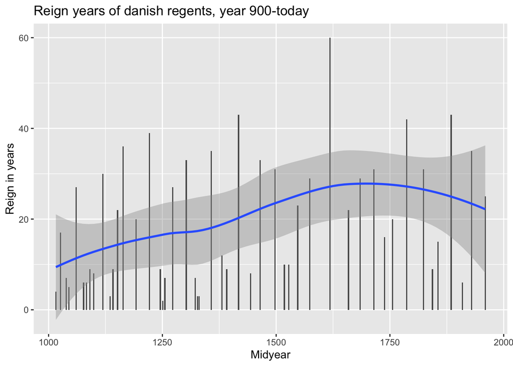

```r
danish_regents %>%
  mutate(Midyear=End_of_reign-(End_of_reign-Start_of_Reign)/2) %>%
  ggplot(aes(x=Midyear, y=Reign_Sum))+
  geom_col()+
  geom_smooth()+
  labs(x="Midyear", y="Reign in years")+
  labs(title="Reign years of danish regents, year 900-today")
```

Comparing the two trends, Homicides in western europe (specificly the scandinavian countries) and the reign og danish regents we can see individual trends and can try to make connections.

We can perhaps relate the stability in the Scandinavian rulers as a factor for less homicides per 100k people. We must though, take into acount that there is missing data, and that there perhaps is further explaination as to why, the homicides are declining.

#Final tasks

1. Plot: In the facetted plot above, move the legend from the current position on the side to below the facets, and label it “Country” instead of “Entity”.

as seen before, we include our code again.

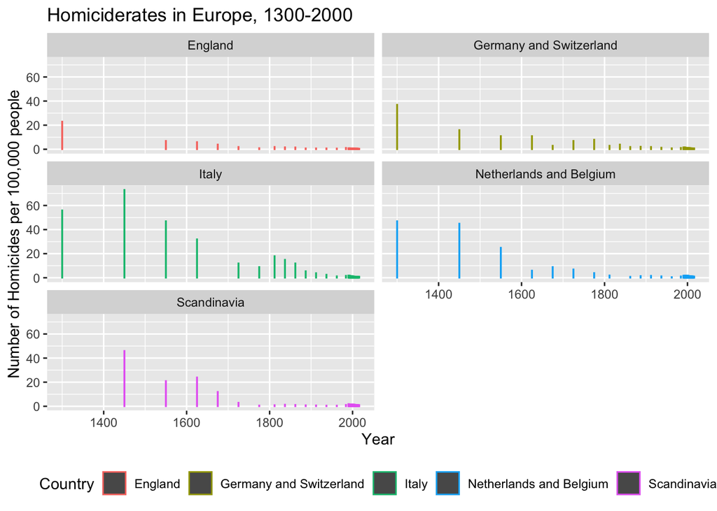

```r
ggplot(data = Western_Europe) +
 geom_col(aes(x = year, y = homicides_per_100k, color = entity)) +
  facet_wrap(~entity, ncol=2)+
  labs(title = "Homiciderates in Europe, 1300-2000") +
  labs(x = "Year", y = "Number of Homicides per 100,000 people") +
  labs(color = "Country")+
  theme(legend.position = "bottom")
```

2. Rmarkdown:
- edit the author of the document, and convert ‘Final Tasks’ into heading #2 (like the other headings)
- add a `floating table of contents` to your Rmarkdown document,
- provide informative `chunk-names` and edit flags in your R chunks, and
- automatically generate a `timestamp` to show when the document was last updated. (Hint: check the Rmarkdown episode in our Data Carpentry tutorial)
3. Question: In <250 words articulate your answer on the basis of the data visualisations to the following question: are we more civilized today?

You can never truly tell if we are more civilized today trough these vizualization, while there is a lot of socioeconomic and enviormental factor, which we do not count for in these functions. We can though, through arguments, see some tendencies which could point to our civilization being more civilized today. We are able to see a downgoing regresion in the western homicides and an upgoing regresion in the sum time of danish regents reign. We could argue that a more stable country ruler defines a more civilezed country while it also points to a downgoing in homicides (at least in the countries of Scandinavia). We know that the trend of more steady sat rulers was relevant in other western countries and that their homicides also went down from the time measured to today. So one can conclude that by not killing eachother, as much, anymore, gives a more civilezed world.